# Escooters: Predictive Modelling

Luca Baggi

# Load Packages

```r
library(tidymodels)
library(tidyverse)

# for skimming data
library(skimr)

# for downsampling
library(themis)

# for visualising importance of predictors
library(vip)
```

Then proceed to importing the data.

# Data and Final Feature Engineering

```r
url = 'https://raw.githubusercontent.com/baggiponte/escooters-louisville/main/data/escooters_od.csv'

trips <-
  # read the data
  read_csv(url, col_types = cols(
    StartTime = col_datetime(format = '%Y-%m-%d %H:%M:%S')
  )) %>%
  # remove unneded cols
  select(-TripID, -EndTime) %>%
  # remove the outliers
  filter(
    # Duration between 0 and 30 minutes
    Duration > 0 & Duration <= 30 &
      # Distance between 0 and 5km
      Distance > 0 & Distance <= 5000
  ) %>%
  # manipulate cols:
  mutate(
    # turn into factors
    StartNH = as.factor(StartNH),
    EndNH = as.factor(EndNH),
    # first covid death reported is on March 21st, 2020
    Covid = as.factor(ifelse(StartTime > '2020-03-20 23:59:59', 1, 0))
  ) %>%
  # reduce the number of levels in the factor features
  mutate(
    # select those with p > 10e-02
    StartNH = fct_lump(StartNH, 5),
    EndNH = fct_lump(EndNH, 5)
  ) %>%
  select(-Duration, -Distance,
         -EndLongitude, -EndLatitude
  ) %>%
  as_tibble()
```

And to visualise it:

```r
skim(trips)
```

```
── Data Summary ────────────────────────
                           Values
Name                       trips
Number of rows             385740
Number of columns          6
_______________________
Column type frequency:
  factor                   3
  numeric                  2
  POSIXct                  1
________________________
Group variables            None

── Variable type: factor ────────────────────────────────────────────────────────────────────────────
  skim_variable n_missing complete_rate ordered n_unique
1 StartNH               0             1 FALSE          6
2 EndNH                 0             1 FALSE          6
3 Covid                 0             1 FALSE          2
  top_counts
1 Dow: 189574, Uni: 109091, Sou: 38390, Wes: 20171
2 Dow: 183399, Uni: 109764, Sou: 39004, Wes: 18039
3 0: 368432, 1: 17308

── Variable type: numeric ───────────────────────────────────────────────────────────────────────────
  skim_variable  n_missing complete_rate  mean     sd    p0   p25   p50   p75  p100 hist
1 StartLatitude          0             1  38.2 0.0182  38.1  38.2  38.2  38.3  38.3 ▁▁▆▇▁
2 StartLongitude         0             1 -85.7 0.0173 -85.9 -85.8 -85.8 -85.7 -85.5 ▁▇▁▁▁

── Variable type: POSIXct ───────────────────────────────────────────────────────────────────────────
  skim_variable n_missing complete_rate min                 max                 median
1 StartTime             0             1 2018-08-09 10:30:00 2020-07-08 08:30:00 2019-07-08 19:00:00
  n_unique
1    42825
```

Let’s use a groupby (literally the same thing as creating a twoway frequency table, but keeps the coltypes!) to visualise the class imbalance:

```r
# groupby frequency table
trips %>%
  mutate(count = 1) %>%
  group_by(StartNH, EndNH) %>%
  summarise(n = sum(count)) %>%
  arrange(desc(n))
```

| StartNH | EndNH | n |
| --- | --- | --- |
| Downtown | Downtown | 166941 |
| University | University | 87586 |
| Southeast Core | Southeast Core | 30802 |
| West Core | University | 12352 |
| University | West Core | 10027 |
| Northeast Core | Northeast Core | 8349 |
| Other | Other | 7789 |
| Downtown | Northeast Core | 7125 |
| Downtown | University | 6445 |
| West Core | West Core | 6289 |

[output cut: 26 more lines]

# Split in Train and Test Data

Class imbalance leads to stratified sampling:

```r
set.seed(42)

trips_split <- initial_split(trips, strata = EndNH)

trips_train <- training(trips_split)
trips_test <- testing(trips_split)
```

Let’s check proportions:

```r
trips_train %>%
  count(EndNH) %>%
  mutate(prop = n/sum(n)) %>%
  arrange(desc(prop))
```

| EndNH | n | prop |
| --- | --- | --- |
| Downtown | 137587 | 0.47557603 |
| University | 82301 | 0.28447734 |
| Southeast Core | 29252 | 0.10111093 |
| Northeast Core | 13504 | 0.04667722 |
| West Core | 13460 | 0.04652513 |
| Other | 13202 | 0.04563334 |

```r
trips_test %>%
  count(EndNH) %>%
  mutate(prop = n/sum(n)) %>%
  arrange(desc(prop))
```

| EndNH | n | prop |
| --- | --- | --- |
| Downtown | 45812 | 0.47506066 |
| University | 27463 | 0.28478545 |
| Southeast Core | 9752 | 0.10112616 |
| West Core | 4579 | 0.04748325 |
| Northeast Core | 4437 | 0.04601074 |
| Other | 4391 | 0.04553373 |

# Define a recipe

Let’s define a recipe to address this problem. We shall `downsample` the data, which would achieve two goals:

1. Address class imbalance.
2. Reduce computational workload, given our limited resources.

```r
trips_recipe <- trips_train %>%
  recipe(EndNH ~ .) %>%
  # problem: step_date does not extract times!
  step_mutate(HourNum = format(strptime(StartTime,'%Y-%m-%d %H:%M:%S'),'%H')) %>%
  # turn it into a factor
  step_string2factor(HourNum) %>%
  # create factors out of StartTime
  step_date(StartTime, features = c('dow', 'month', 'year')) %>%
  # create holiday dummy:
  step_holiday(StartTime, holidays = timeDate::listHolidays("US")) %>%
  # remove StartTime col
  step_rm(StartTime) %>%
  # turn factor-features into binary dummies (i.e. one per column: 1-0):
  step_dummy(all_nominal(), -all_outcomes()) %>%
  # remove predictors with zero variance:
  step_zv(all_predictors()) %>%
  # downsample the data
  themis::step_downsample(EndNH, under_ratio = 1)
```

Note: `step_mutate(...)`is the same as the following:

```
trips %>%
  mutate(
    HourNum = format(strptime(StartTime,'%Y-%m-%d %H:%M:%S'),'%H')
  )
```

In the last step, by setting `under_ratio` we bring the number of samples of all majority classes equal to some percentage of the minority class, in this case `other`. This seems reasonable, as `Downtown` is more than 10 times more frequent than `other`. While we may want to use the package `tune` to choose the appropriate `under_ratio`, due to some hardware constraints we have to give up.

Now we can start thinking of our models!

# Logistic Regression

## Model Specification

Normally, to specify a logistic regression, one would use `logistic_reg()`, perhaps with the engine `glm`. However, for multinomial regressions one must use `multinom_reg()` and said engine is unavailable:

```r
show_engines('multinom_reg')
```

| engine | mode |
| --- | --- |
| glmnet | classification |
| spark | classification |
| keras | classification |
| nnet | classification |

Specifying the `mode` is redundant: the only one available is `classification`, as one can see above.

```r
logistic_model <- multinom_reg(penalty = 0) %>%
  set_engine('glmnet') # this is actually the default
```

Then we create a workflow:

```r
logistic_workflow <- workflow() %>%
  add_recipe(trips_recipe) %>%
  add_model(logistic_model)

logistic_workflow
```

```
══ Workflow ═════════════════════════════════════════════════════════════════════════════════════════
Preprocessor: Recipe
Model: multinom_reg()

── Preprocessor ─────────────────────────────────────────────────────────────────────────────────────
8 Recipe Steps

● step_mutate()
● step_string2factor()
● step_date()
● step_holiday()
● step_rm()
● step_dummy()
● step_zv()
● step_downsample()

── Model ────────────────────────────────────────────────────────────────────────────────────────────
Multinomial Regression Model Specification (classification)

Main Arguments:
  penalty = 0

Computational engine: glmnet
```

## Model Fitting

```r
logistic_fit <- logistic_workflow %>%
  fit(data = trips_train)
```

And extract the results:

```r
logistic_fit %>%
  pull_workflow_fit() %>%
  tidy() %>%
  select(-penalty)
```

| class | term | estimate |
| --- | --- | --- |
| Downtown | (Intercept) | -3.683146e+03 |
| Downtown | StartLatitude | 8.394295e+01 |
| Downtown | StartLongitude | -2.180391e+01 |
| Downtown | StartTime_year | -1.396370e-01 |
| Downtown | StartTime_USChristmasDay | -1.890087e-01 |
| Downtown | StartTime_USColumbusDay | -6.851282e-01 |
| Downtown | StartTime_USCPulaskisBirthday | 4.822993e-01 |
| Downtown | StartTime_USDecorationMemorialDay | 2.695938e-01 |
| Downtown | StartTime_USElectionDay | -2.018949e-01 |
| Downtown | StartTime_USGoodFriday | -1.220107e+00 |

[output cut: 392 more lines]

Let’s see the contribution of each variable:

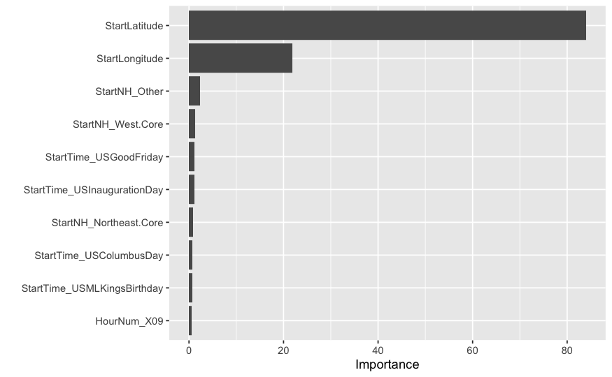

```r
logistic_fit %>%
  pull_workflow_fit() %>%
  vip()
```

This is unexpected! Results can be improved by `tuning` the `penalty` hyperparameter (Multinomial Lasso/Ridge/ElasticNet).

## Predictions

Just a function’s call:

```r
logistic_predictions <- logistic_fit %>%
  # bind cols with classes predicted probabilites
  predict(trips_test) %>%
  # bind the actual outcome
  bind_cols(trips_test %>% select(EndNH))

logistic_predictions
```

| .pred_class | EndNH |
| --- | --- |
| Southeast Core | University |
| Southeast Core | Downtown |
| Downtown | Downtown |
| University | Other |
| Southeast Core | Southeast Core |
| Downtown | University |
| Downtown | Downtown |
| Northeast Core | Downtown |
| Downtown | Downtown |
| Downtown | Downtown |

[output cut: 990 more lines]

## Model Evaluation

Unfortunately, collecting the metrics with `collect_metrics()` can’t be done with `multinomial_reg()` (yet). Let’s start with the confusion matrix:

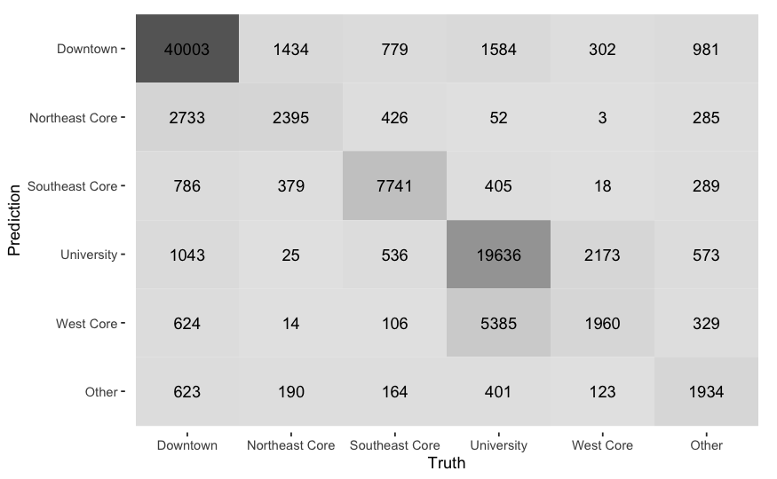

```r
logistic_predictions %>%
  conf_mat(EndNH, .pred_class) %>%
  autoplot(type = 'heatmap')
```

Unfortunately, collecting the metrics with `collect_metrics()` can’t be done with `multinomial_reg()` (yet).

```r
logistic_predictions %>%
  accuracy(EndNH, .pred_class)
```

| .metric | .estimator | .estimate |
| --- | --- | --- |
| accuracy | multiclass | 0.7639318 |

Not as bad as I initially thought!